# *Feature Scaling Standardization vs Normalization*

*Feature scaling is an integral part of feature engeenering.*

*It is not neessary that we use feature scaling in each and every algorithm.*

```python
# The data which we collect will include "Independent feature x" and "Dependent feature y".

# With the help of the independent feature we will predict the dependent feature in "SUPERVISED MACHINE LEARNING."
```

*When you consider these features these features has " 2 important properties"*

*1) Unit*

*2) Magnitude*

```python
# if I consider feature " AGE " the unit which is basically used to calculate " AGE " is number of years.
# from his Date of birth how many number of years has been happended.
```

```python
# if I consder about Magnitude that is basically the value. Suppose if I say 25 years , the 25 is the magnitude and years is
# basically the unit.
```

*For each and every feature this will be there. It will be either calculated with the help of "units and magnitude".*

*NOTE: It is very necessay that for a machine learning algorithm the data what we provide we should try to scale down that data into some scale.*

# *The two scales that we use is:*

## *1) Normalization*

## *2) Standardization*

# *Normalization :*

normalization helps you to scale down your feature from 0 to 1.

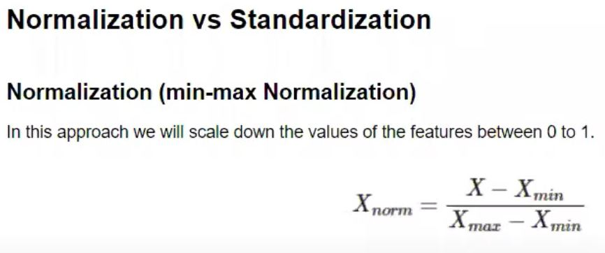

# *Standarization :*

standardization helps you to scale down your feature based on standard normal distribution. Over here the mean is usually 0 and standardeviation is usually 1.

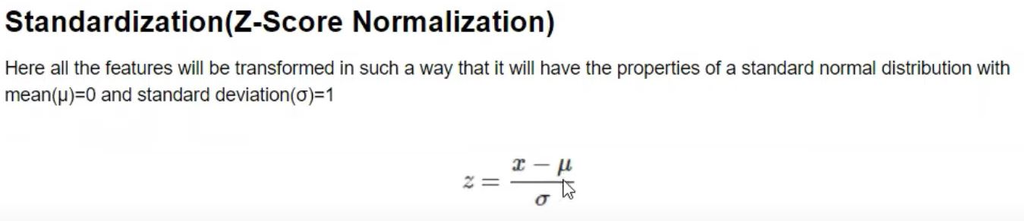

```python
import numpy as np
import pandas as pd
import matplotlib.pyplot as plt
import seaborn as sns
%matplotlib inline
```

```python
FILEPATH = "E:\PYTHON\Sep 3rd Practice Complete ML\Top mentor on Oct 11\Top mentor New DataSETS OCT 09\Top mentor Regression Hackathon\Hackathon_Working_Data.csv"
```

```python
import warnings
warnings.filterwarnings('ignore')
```

```python
Hackathon = pd.read_csv(r"E:\PYTHON\Sep 3rd Practice Complete ML\Top mentor on Oct 11\Top mentor New DataSETS OCT 09\Top mentor Regression Hackathon\Hackathon_Working_Data.csv", usecols= [0,1,2,3,4,5,6,7])
```

```python
Hackathon.head()
```

|  | MONTH | STORECODE | DAY | BILL_ID | BILL_AMT | QTY | VALUE | PRICE |
| --- | --- | --- | --- | --- | --- | --- | --- | --- |
| 0 | M1 | N1 | 4 | T375 | 225.0 | 1.0 | 225.0 | 225.0 |
| 1 | M1 | N1 | 4 | T379 | 95.0 | 1.0 | 95.0 | 95.0 |
| 2 | M1 | N1 | 4 | T381 | 10.0 | 1.0 | 10.0 | 10.0 |
| 3 | M1 | N1 | 4 | T382 | 108.0 | 1.0 | 108.0 | 108.0 |
| 4 | M1 | N1 | 4 | T384 | 19.0 | 1.0 | 19.0 | 19.0 |

```python
hack = Hackathon.copy()
```

```python
hack.head()
```

|  | MONTH | STORECODE | DAY | BILL_ID | BILL_AMT | QTY | VALUE | PRICE |
| --- | --- | --- | --- | --- | --- | --- | --- | --- |
| 0 | M1 | N1 | 4 | T375 | 225.0 | 1.0 | 225.0 | 225.0 |
| 1 | M1 | N1 | 4 | T379 | 95.0 | 1.0 | 95.0 | 95.0 |
| 2 | M1 | N1 | 4 | T381 | 10.0 | 1.0 | 10.0 | 10.0 |
| 3 | M1 | N1 | 4 | T382 | 108.0 | 1.0 | 108.0 | 108.0 |
| 4 | M1 | N1 | 4 | T384 | 19.0 | 1.0 | 19.0 | 19.0 |

```python
hack.columns
```

```
Index(['MONTH', 'STORECODE', 'DAY', 'BILL_ID', 'BILL_AMT', 'QTY', 'VALUE',
       'PRICE'],
      dtype='object')
```

```python
hack.columns = map(str.capitalize,hack.columns)
```

```python
hack.columns
```

```
Index(['Month', 'Storecode', 'Day', 'Bill_id', 'Bill_amt', 'Qty', 'Value',
       'Price'],
      dtype='object')
```

# *Normalization*

```python
from sklearn.preprocessing import MinMaxScaler
```

```python
scaling = MinMaxScaler()
```

```python
scaling.fit_transform(hack[['Bill_amt', 'Value']])
```

```
array([[0.03085573, 0.07142857],
       [0.01302798, 0.03015873],
       [0.00137137, 0.0031746 ],
       ...,
       [0.01206802, 0.00634921],
       [0.01206802, 0.0184127 ],
       [0.00205705, 0.0047619 ]])
```

```python
# converting back to DataFrame.

hack[['Bill_amt', 'Value']] = pd.DataFrame(scaling.fit_transform(hack[['Bill_amt', 'Value']]))
```

```python
hack.head()   # we see the 'Bill_amt' and "Value" columns are scaled down to 0 to 1
```

|  | Month | Storecode | Day | Bill_id | Bill_amt | Qty | Value | Price |
| --- | --- | --- | --- | --- | --- | --- | --- | --- |
| 0 | M1 | N1 | 4 | T375 | 0.030856 | 1.0 | 0.071429 | 225.0 |
| 1 | M1 | N1 | 4 | T379 | 0.013028 | 1.0 | 0.030159 | 95.0 |
| 2 | M1 | N1 | 4 | T381 | 0.001371 | 1.0 | 0.003175 | 10.0 |
| 3 | M1 | N1 | 4 | T382 | 0.014811 | 1.0 | 0.034286 | 108.0 |
| 4 | M1 | N1 | 4 | T384 | 0.002606 | 1.0 | 0.006032 | 19.0 |

# *Standardization (Z-score Normalization)*

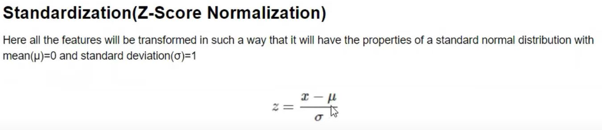

```python
hk = Hackathon.copy()
```

```python
hk.head()
```

|  | MONTH | STORECODE | DAY | BILL_ID | BILL_AMT | QTY | VALUE | PRICE |
| --- | --- | --- | --- | --- | --- | --- | --- | --- |
| 0 | M1 | N1 | 4 | T375 | 225.0 | 1.0 | 225.0 | 225.0 |
| 1 | M1 | N1 | 4 | T379 | 95.0 | 1.0 | 95.0 | 95.0 |
| 2 | M1 | N1 | 4 | T381 | 10.0 | 1.0 | 10.0 | 10.0 |
| 3 | M1 | N1 | 4 | T382 | 108.0 | 1.0 | 108.0 | 108.0 |
| 4 | M1 | N1 | 4 | T384 | 19.0 | 1.0 | 19.0 | 19.0 |

```python
pd.options.display.max_columns = None
```

```python
pd.options.display.max_rows = 20
```

```python
from sklearn.preprocessing import StandardScaler
```

```python
scaling = StandardScaler()
```

```python
scale = scaling.fit_transform(hk[['BILL_AMT','VALUE']])
```

```python
scale
```

```
array([[-0.09942033,  1.33153897],
       [-0.33948537,  0.2301883 ],
       [-0.49645097, -0.48992561],
       ...,
       [-0.35241195, -0.40520632],
       [-0.35241195, -0.08327305],
       [-0.4872177 , -0.44756597]])
```

```python
hk[['BILL_AMT', 'VALUE']] = pd.DataFrame(scale)  # convertung the columns back to dataframe
```

```python
hk.head()
```

|  | MONTH | STORECODE | DAY | BILL_ID | BILL_AMT | QTY | VALUE | PRICE |
| --- | --- | --- | --- | --- | --- | --- | --- | --- |
| 0 | M1 | N1 | 4 | T375 | -0.099420 | 1.0 | 1.331539 | 225.0 |
| 1 | M1 | N1 | 4 | T379 | -0.339485 | 1.0 | 0.230188 | 95.0 |
| 2 | M1 | N1 | 4 | T381 | -0.496451 | 1.0 | -0.489926 | 10.0 |
| 3 | M1 | N1 | 4 | T382 | -0.315479 | 1.0 | 0.340323 | 108.0 |
| 4 | M1 | N1 | 4 | T384 | -0.479831 | 1.0 | -0.413678 | 19.0 |

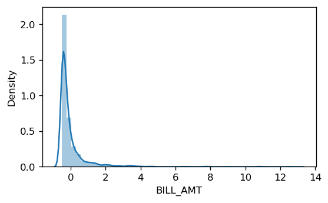

```python
# Visualization

plt.figure(figsize= (5,3), dpi= 120)
sns.distplot(hk['BILL_AMT'])
```

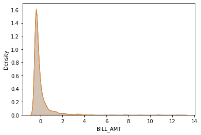

```python
# KDE

for col in 'xy':
    sns.kdeplot(hk['BILL_AMT'], shade = 'fill')
```

# *When to use Standardization and Normalization?*

*Whenevr you are using some machine learning algorithms which involves "Euclidean distance" and suppose in some of the deep learning techniques where "Gradient Distance" is basicaly involved. "Gradient Distance means where the parabola curve where you need to find the best/global minimal point OR in order to retrieve that minimal point we have to scale down that particular values."*

```python
# Some of the Algorithms like KNN (K-nearest neighbor), K-means Clustering and all the deep learning algorithms like

# Artificial Neural Networks , Linear Regression and Logistic Regression we have to use
```

# Scaling which Algorithms we have to use

### KNN, K-means , Linear Regression, Logistic Regression

# Scaling which Algorithms not to use

### Decision Trees, Random Forest, Xgboost algorithms we do not have to use the Scaling

# *On which Algorithms should we use Normalization (min-max Scalar)*

*Where the feature is like for photo which has 0 to 250 pixels we have to use min-max Scalar*

# *On other algorithms we can use the Standardization technique which is the best.*